# Setting up API in Twitter

MariaProkofieva

02/12/2018

### Resources

[FAQ Twitter Developer Account](https://developer.twitter.com/en/docs/accounts-and-users/subscribe-account-activity/FAQ.html) [Setting API for rtweet](https://rtweet.info/articles/auth.html)

### Before you start

To connect to Twitter from R, you need to have a Twitter account. You can create it [here](https://twitter.com/signup) You need to note down your `username` and `password`

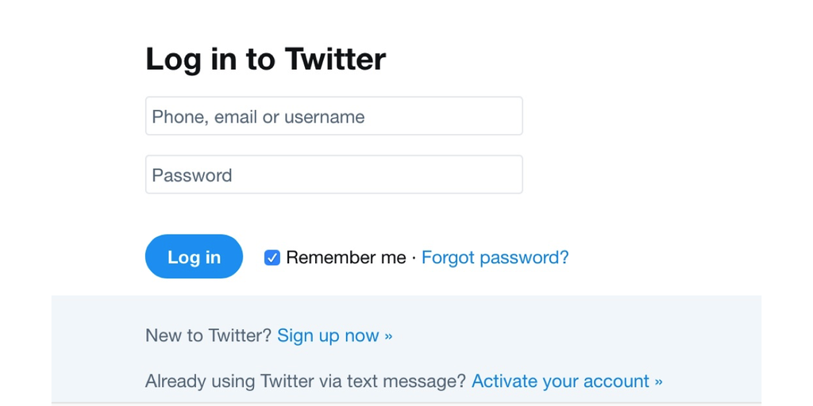

Now go to https://apps.twitter.com/ and sign in with your `username` and `password`

There you will need to set up your developer’s access: click on `Apply for a developer account`

[figure not shown]

Twitter Apps

Select a Twitter username for which you are setting up your developer’s access

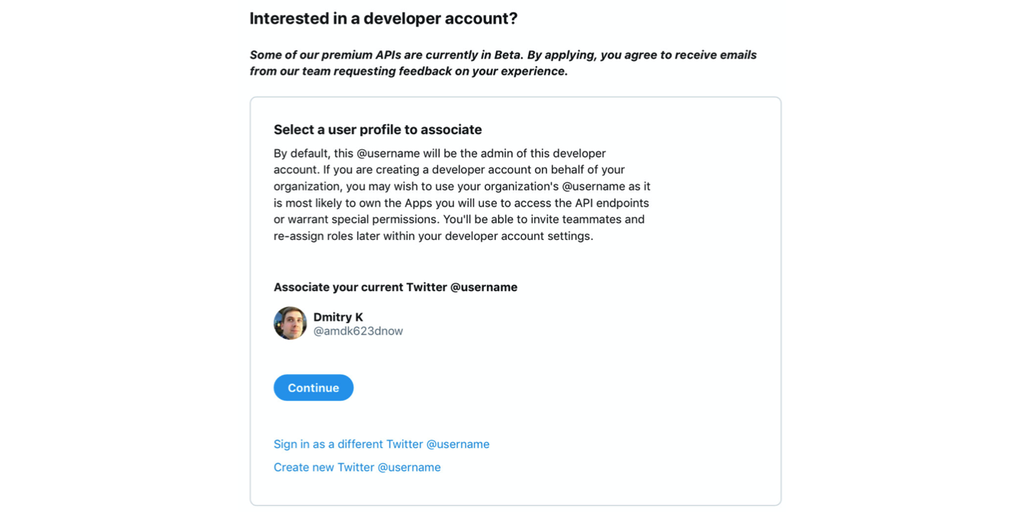

On the next screen select the option that better suit your needs, for our tutorial, we will be using option 2 `I am requesting access for my own personal use`

[figure not shown]

Now you need to specify your application name and your country

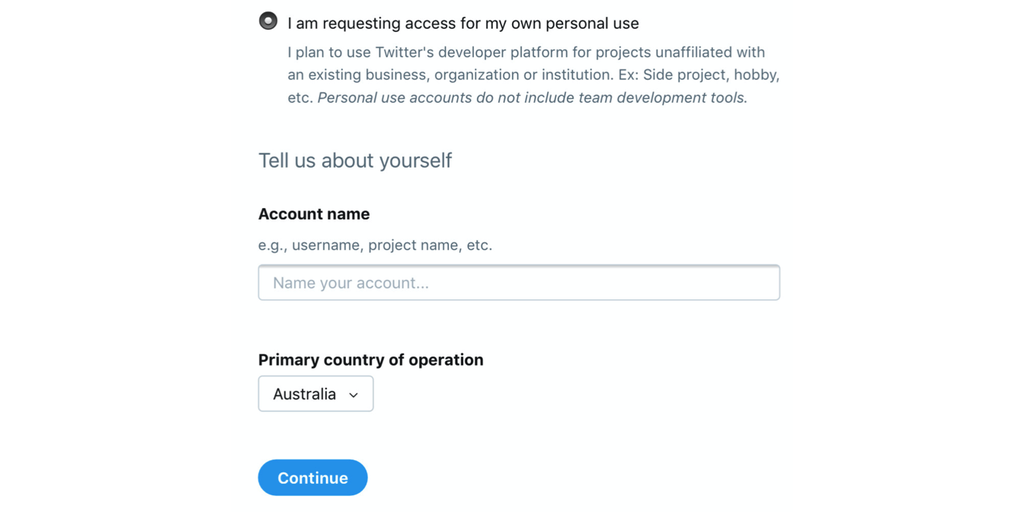

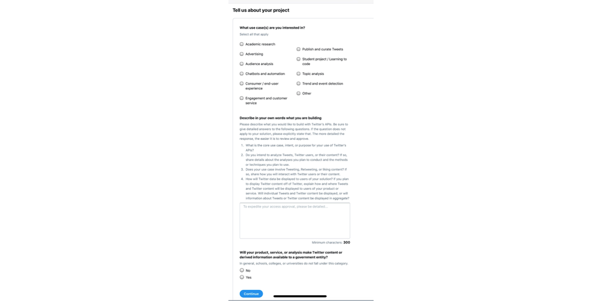

For example, like this

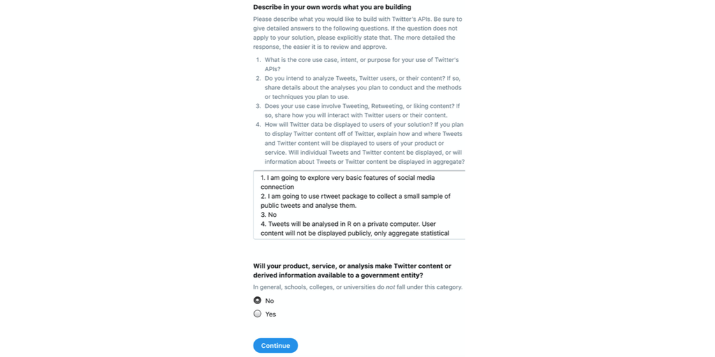

Now, you click submit and you will need to wait till Twitter approves your access

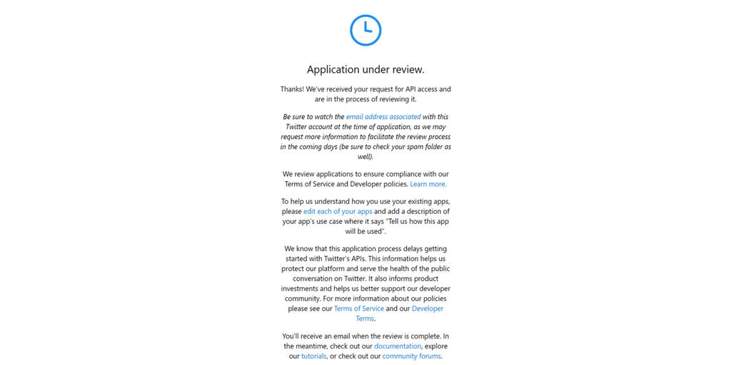

_______________

Once your access is approved, your Developer account will look like this

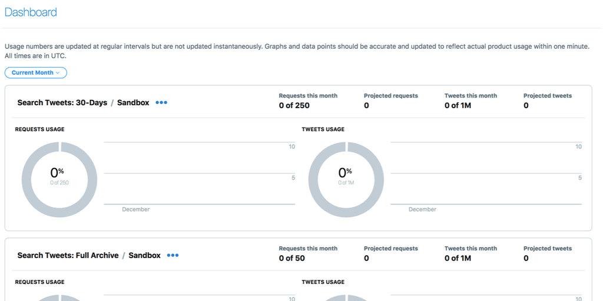

and you can set up your Twitter app now by clicking on `Create an app`

[figure not shown]

Enter the details for your application:

- `brief description`
- `website`
- `callback URL`, please set to http://127.0.0.1:1410

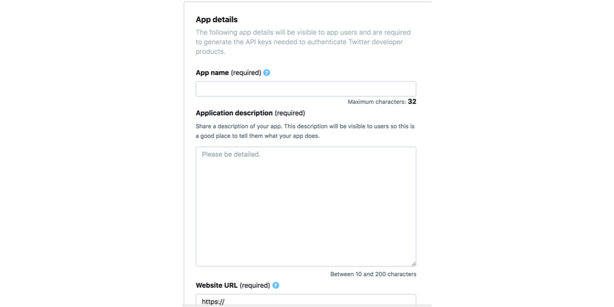

Click on `Create a new App`

Go to the `Keys and Access Tokens` tab and click on `Create my access token`

[figure not shown]

You need to write down (copy and paste!) the details of your access:

- API key
- API secret
- Token
- Token secret

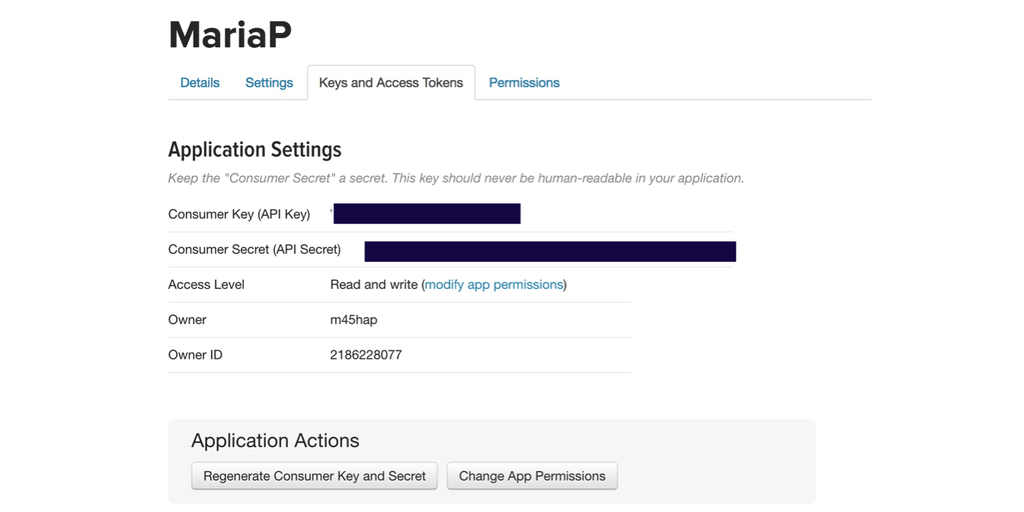

Create a Twitter app at https://apps.twitter.com/.

and now you can go back to R and connect from R!